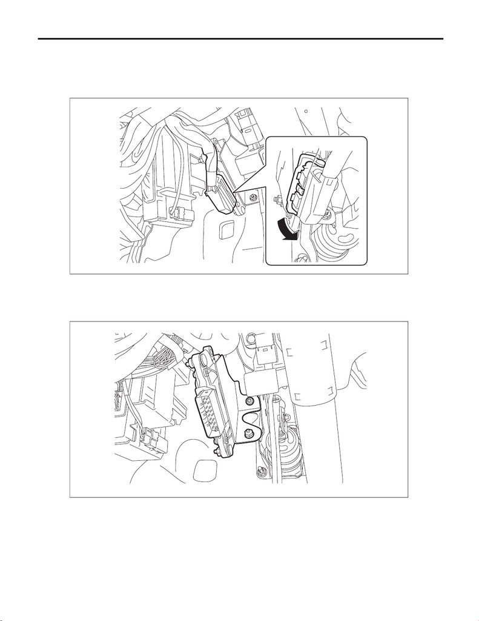

CVT(TR690)-126

Transmission Control Module (TCM)

CONTINUOUSLY VARIABLE TRANSMISSION

22.Transmission Control Module (TCM)

A: REMOVAL

1) Disconnect the ground terminal from battery sensor. <Ref. to NT-5, BATTERY, NOTE, Note.>

2) Move the lock lever in the arrow direction while pressing the lock button, and disconnect the connector.

3) Remove the TCM.

(A) Lock button

(B) Lock lever

CVT00501

(B) (A)

CVT00503

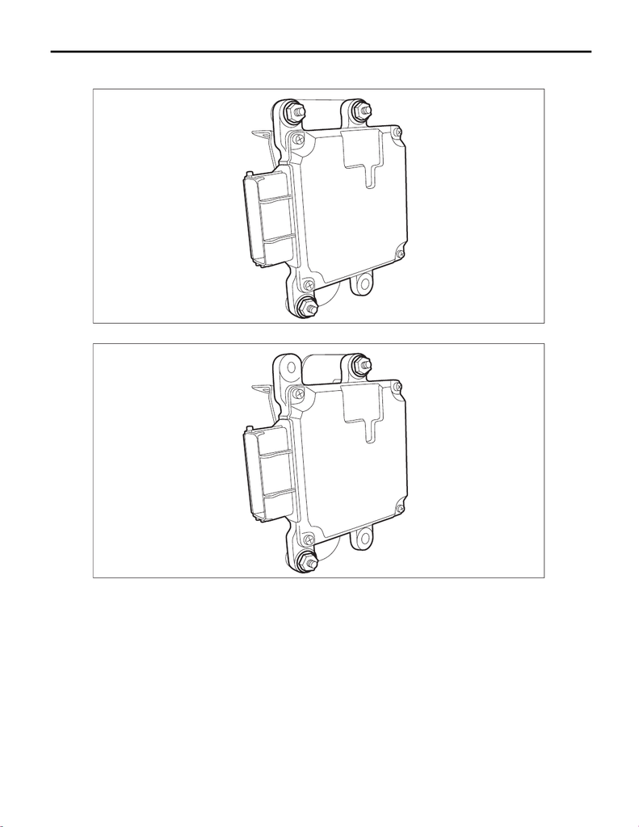

CVT(TR690)-127

Transmission Control Module (TCM)

CONTINUOUSLY VARIABLE TRANSMISSION

4) Remove the TCM from the bracket.

• Type A

• Type B

CVT00504

CVT01236

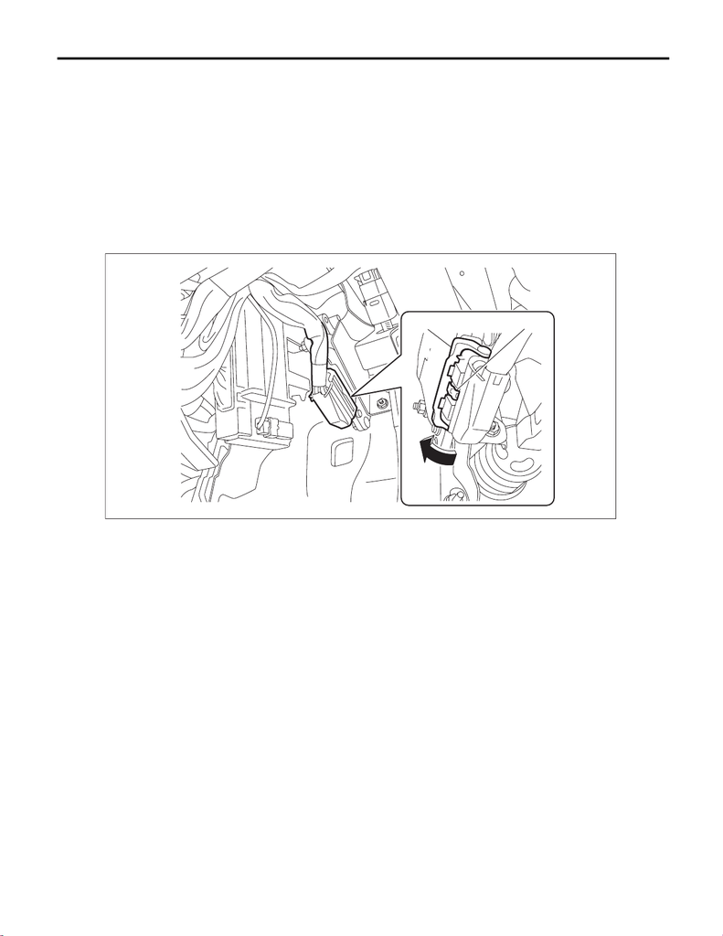

CVT(TR690)-128

Transmission Control Module (TCM)

CONTINUOUSLY VARIABLE TRANSMISSION

B: INSTALLATION

1) Install the TCM to the bracket.

Tightening torque:

7.5 N·m (0.8 kgf-m, 5.5 ft-lb)

2) Install the TCM.

Tightening torque:

7.5 N·m (0.8 kgf-m, 5.5 ft-lb)

3) Install the harness connector to TCM.

NOTE:

• Install the connector in the reverse order of removal.

• Move the lock lever in the arrow direction, and confirm that a clicking sound is heard.

4) Connect the ground terminal to battery sensor. <Ref. to NT-5, BATTERY, NOTE, Note.>

5) Perform the operation of AT learning mode. <Ref. to CVT(diag)-23, Learning Control.>

(A) Lock button

(B) Lock lever

CVT00591

(B)

(A)